# R Notebook

# This code is running using R notebook in RStudio

**Goul:**

Our main goal in collecting the Arab Employee dataset is to learn more about what affects how much Arab professionals get paid. We want to gather information about their qualifications, where they live, and how much experience they have. This data will help organizations and policymakers make better decisions about managing talent, planning for the future workforce, and making sure pay is fair in the Arab region.

**Here are two specific goals we have for this dataset:**

**Classification Goal:** We want to group employees into different categories based on their qualifications, country location, and experience. By doing this, we can see patterns and trends among different groups. This will help us understand if there are differences in pay based on qualifications and experience, and it will help us identify talented individuals. With this information, we can develop strategies to support career growth and make sure people are being paid fairly.

**Defect Prediction Goal:** We want to use machine learning and statistical techniques to create models that can predict any issues or anomalies with employee salaries. This could include things like unfair pay practices, wage gaps, or differences based on qualifications or experience. By catching these problems early, we can fix them and make sure everyone is being treated fairly. This analysis will help us improve compensation policies and make better decisions about managing talent.

**By achieving these goals, we can:**

Understand how salaries are distributed among different employee groups. Identify any biases or unfairness in pay based on qualifications, experience, or location. Develop strategies for hiring, developing, and keeping talented employees. Make sure pay practices are fair and transparent. Catch and fix salary-related issues before they become bigger problems. Plan for the future workforce and allocate resources effectively. Make better decisions about pay and talent management in the Arab region. Overall, collecting the Arab Employee dataset with information about salary, qualifications, location, and experience is really important. It will help us analyze the data and make fair decisions that create a good working environment for Arab professionals.

**Source of the dataset:** Kaggle

**link of the dataset:** https://www.kaggle.com/datasets/qusaybtoush1990/employes

**General Information about Employees dataset:**

Our dataset contains 10 attributes (See Table 1), and 740 objects. Furthermore, class lables the class label for our dataset is Salary.

*Table 1: General Information about the attributes for Employees dataset.*

[output not shown]

#Sample of Employees dataset

```r
View(Employees)
```

#Number of column and rows

```r
dim(Employees)
```

```
[1] 740  10
```

#statiscal summarise -Nominal-

```r
summary(Employees$Education)
```

```
   Length     Class      Mode
      740 character character
```

```r
summary(Employees$Department)
```

```
   Length     Class      Mode
      740 character character
```

```r
summary(Employees$'Job Status')
```

```
   Length     Class      Mode
      740 character character
```

```r
summary(Employees$Location)
```

```
   Length     Class      Mode
      740 character character
```

#statiscal summarise -Numerical-

```r
summary(Employees$Years)
```

```
   Min. 1st Qu.  Median    Mean 3rd Qu.    Max.    NA's
  1.000   2.000   4.000   4.341   6.000   9.000      72
```

```r
summary(Employees$Salary)
```

```
   Min. 1st Qu.  Median    Mean 3rd Qu.    Max.
  650.0   970.8  1580.5  1517.6  2074.0  2500.0
```

```r
summary(Employees$'Job Rate')
```

```
   Min. 1st Qu.  Median    Mean 3rd Qu.    Max.
  1.000   3.000   5.000   5.292   8.000  13.000
```

```r
summary(Employees$Permissions)
```

```
   Min. 1st Qu.  Median    Mean 3rd Qu.    Max.
  1.000   4.000   7.000   7.435  11.000  14.000
```

Description of summary: This is the summary of all data set

#Code for variance

```r
var(Employees$Salary)
```

```
[1] 353862
```

#Graphs

#Box plot for salary and years

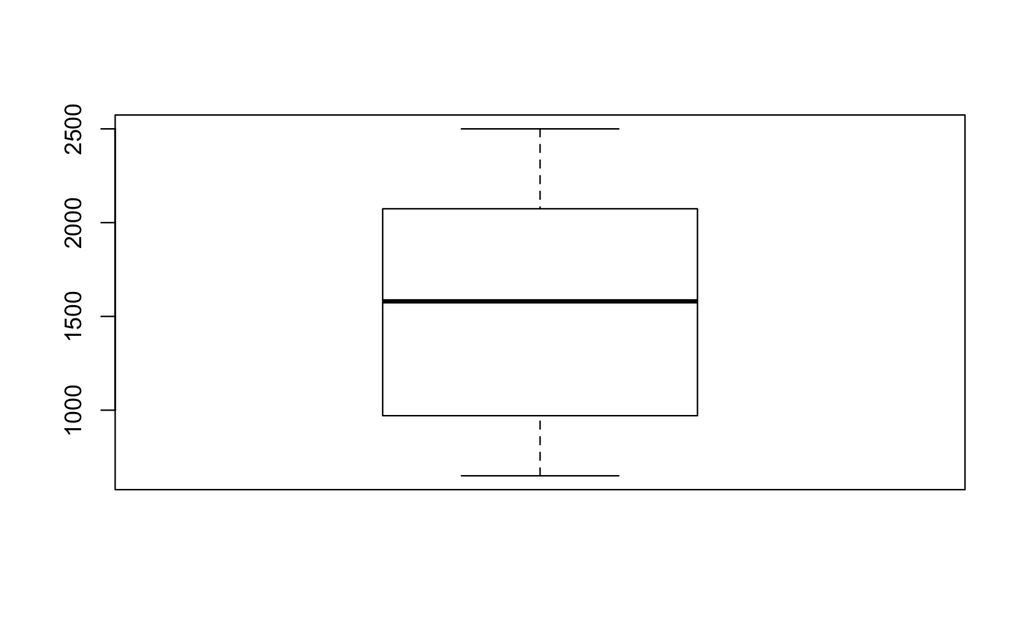

```r
boxplot(Employees$Salary)
```

Description for Salary boxplot: The Salary boxplot illustrates that the salaries are evenly distributed around the middle point, indicating a relatively balanced salary distribution.

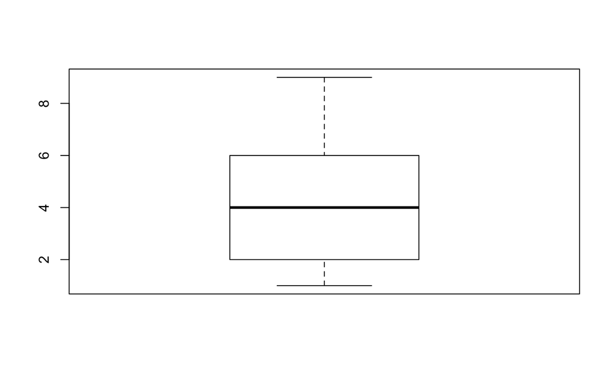

```r
boxplot(Employees$Years)
```

Description for Years boxplot: The Years of Work boxplot illustrates how the values in the dataset have relatively balanced around the median value of 4.

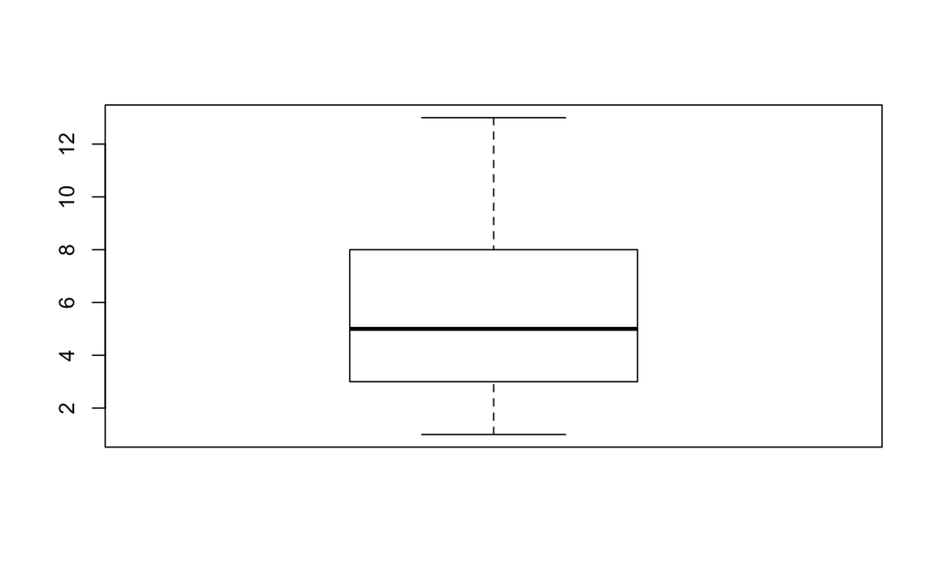

```r
boxplot(Employees$'Job Rate')
```

Description for Job rate boxplot: The Job rate boxplot is relatively balanced around the median value of 5. In a more comprehensive analysis, there is a spread in the job rates above 50% of the dataset.

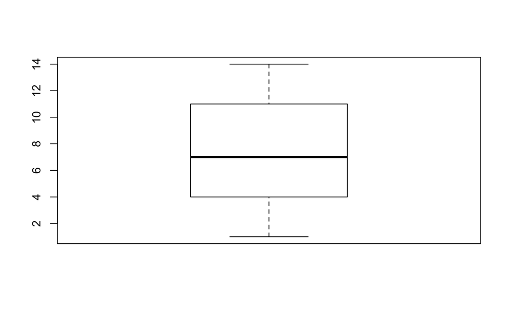

```r
boxplot(Employees$Permissions)
```

Description for Permissions boxplot: The Permissions boxplot reveals several important insights about the distribution of Permissions. It illustrates that the values of the attribute are almost balanced near to the median.

#Histogram for permission

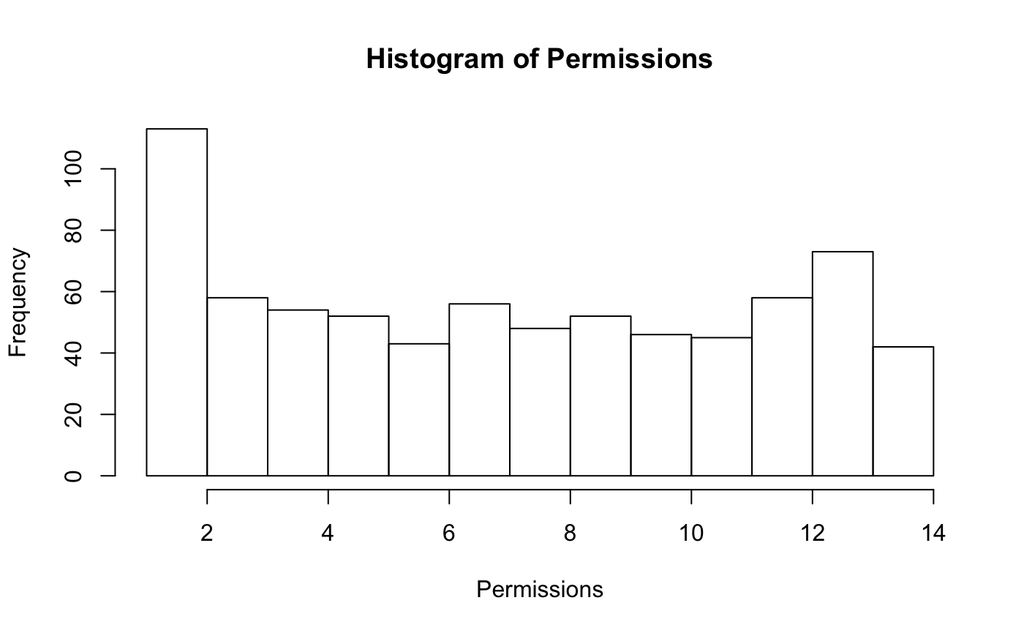

```r
Permissions <- Employees$Permissions
hist(Permissions)
```

#pie chart fo job status

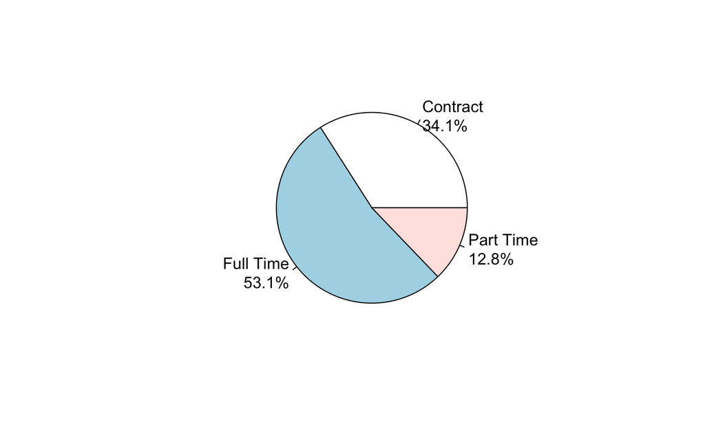

```r
tab <- Employees$'Job Status' %>% table()
precentages <- tab %>% prop.table() %>% round(3) * 100
txt <- paste0(names(tab), '\n', precentages, '%')
pie(tab, labels=txt)
```

Description for Job Status pie chart: The pie chart shows that more than half of the employees work as a full-time jub. In addition to this, it will helps us determine salaries for each employee according to their Job Status.

#pie chart for Education

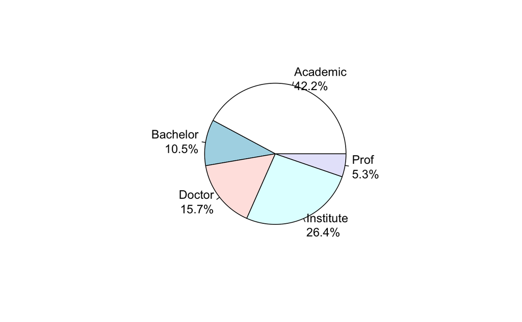

```r
tab <- Employees$Education %>% table()
precentages <- tab %>% prop.table() %>% round(3) * 100
txt <- paste0(names(tab), '\n', precentages, '%')
pie(tab, labels=txt)
```

#Data preprocessing #Data cleaning

#to find the total null values in the dataset

```r
dim(Employees)
```

```
[1] 740  10
```

```r
sum(is.na(Employees))
```

```
[1] 72
```

#Replace missing Data with average value

```r
Employees$Years = ifelse(is.na(Employees$Years), ave(Employees$Years, FUN =function(x) mean(x,na.rm=TRUE)), Employees$Years)
View(Employees)
```

Description of data cleaning: We checked if our data contains missing or null values and replace these missing values with average value to get more efficient dataset.

#Detecting outliers

```r
OutSalary = outlier(Employees$Salary, logical =TRUE)
sum(OutSalary)
```

```
[1] 1
```

```r
Find_outlierSalary = which(OutSalary ==TRUE, arr.ind = TRUE)
OutSalary
```

[output not shown]

[output cut: 35 more lines]

```r
Find_outlierSalary
```

```
[1] 609
```

```r
OutPermissions = outlier(Employees$Permissions, logical =TRUE)
sum(OutPermissions)
```

```
[1] 42
```

```r
Find_outlierPre = which(OutPermissions ==TRUE, arr.ind = TRUE)
OutPermissions
```

[output not shown]

[output cut: 35 more lines]

```r
Find_outlierPre
```

```
 [1]   1  31  37  60  62  67 106 117 119 126 127 146 147 195 222 229 232 256 258 266 268 284 302
[24] 308 327 338 351 352 355 374 389 475 533 547 548 556 587 641 650 663 675 728
```

```r
OutJobRate= outlier(Employees$'Job Rate', logical =TRUE)
sum(OutJobRate)
```

```
[1] 21
```

```r
Find_outlierJob = which(OutJobRate ==TRUE, arr.ind = TRUE)
OutJobRate
```

[output not shown]

[output cut: 35 more lines]

```r
Find_outlierJob
```

```
 [1]  42  59  77 129 143 229 234 243 255 306 308 328 342 411 413 513 563 579 591 635 709
```

```r
OutYears= outlier(Employees$Years, logical =TRUE)
sum(OutYears)
```

```
[1] 5
```

```r
Find_outlierYears = which(OutYears ==TRUE, arr.ind = TRUE)
OutYears
```

[output not shown]

[output cut: 35 more lines]

```r
Find_outlierYears
```

```
[1] 664 665 666 667 668
```

```r
summary(Employees)
```

```
      ID             Education          Department         Job Status          Location
 Length:740         Length:740         Length:740         Length:740         Length:740
 Class :character   Class :character   Class :character   Class :character   Class :character
 Mode  :character   Mode  :character   Mode  :character   Mode  :character   Mode  :character



   Start Date                      Years           Salary          Job Rate       Permissions
 Min.   :2011-01-07 00:00:00   Min.   :1.000   Min.   : 650.0   Min.   : 1.000   Min.   : 1.000
 1st Qu.:2013-07-15 12:00:00   1st Qu.:3.000   1st Qu.: 970.8   1st Qu.: 3.000   1st Qu.: 4.000
 Median :2015-09-02 12:00:00   Median :4.341   Median :1580.5   Median : 5.000   Median : 7.000
 Mean   :2015-08-25 23:13:17   Mean   :4.341   Mean   :1517.6   Mean   : 5.292   Mean   : 7.435
 3rd Qu.:2017-09-09 00:00:00   3rd Qu.:6.000   3rd Qu.:2074.0   3rd Qu.: 8.000   3rd Qu.:11.000
 Max.   :2020-01-01 00:00:00   Max.   :9.000   Max.   :2500.0   Max.   :13.000   Max.   :14.000
```

```r
str(Employees)
```

```
tibble [740 × 10] (S3: tbl_df/tbl/data.frame)
 $ ID         : chr [1:740] "3N62G8" "8E85U3" "4E11Y3" "4C86X3" ...
 $ Education  : chr [1:740] "Doctor" "Doctor" "Academic" "Academic" ...
 $ Department : chr [1:740] "Training" "Logistics" "Logistics" "Wash" ...
 $ Job Status : chr [1:740] "Contract" "Contract" "Contract" "Contract" ...
 $ Location   : chr [1:740] "Saudi Arabia" "Egypt" "United Arab Emirates" "United Arab Emirates" ...
 $ Start Date : POSIXct[1:740], format: "2018-02-13" "2018-12-14" "2018-03-25" ...
 $ Years      : num [1:740] 1 1 1 1 1 1 1 1 1 1 ...
 $ Salary     : num [1:740] 703 724 757 769 771 798 799 808 815 824 ...
 $ Job Rate   : num [1:740] 1 4 1 3 5 3 1 5 4 3 ...
 $ Permissions: num [1:740] 14 2 7 7 12 13 4 11 3 11 ...
```

```r
#Removing outliers
Employees= Employees[-Find_outlierSalary,]
Employees= Employees[-Find_outlierPre,]
Employees= Employees[-Find_outlierJob,]
Employees= Employees[-Find_outlierYears,]
```

Description of detecting outliers, Removing outliers: This function is used to find outliers-if found- in order to remove them to have better prediction.

```r
summary(Employees)
```

```
      ID             Education          Department         Job Status          Location
 Length:672         Length:672         Length:672         Length:672         Length:672
 Class :character   Class :character   Class :character   Class :character   Class :character
 Mode  :character   Mode  :character   Mode  :character   Mode  :character   Mode  :character



   Start Date                      Years           Salary          Job Rate       Permissions
 Min.   :2011-01-07 00:00:00   Min.   :1.000   Min.   : 650.0   Min.   : 1.000   Min.   : 1.000
 1st Qu.:2013-07-09 18:00:00   1st Qu.:3.000   1st Qu.: 972.5   1st Qu.: 3.000   1st Qu.: 4.000
 Median :2015-08-11 00:00:00   Median :4.341   Median :1585.0   Median : 4.000   Median : 7.000
 Mean   :2015-08-11 10:27:51   Mean   :4.367   Mean   :1515.6   Mean   : 5.269   Mean   : 7.019
 3rd Qu.:2017-08-28 18:00:00   3rd Qu.:6.000   3rd Qu.:2049.2   3rd Qu.: 8.000   3rd Qu.:10.000
 Max.   :2020-01-01 00:00:00   Max.   :9.000   Max.   :2499.0   Max.   :13.000   Max.   :14.000
```

```r
str(Employees)
```

```
tibble [672 × 10] (S3: tbl_df/tbl/data.frame)
 $ ID         : chr [1:672] "8E85U3" "4E11Y3" "4C86X3" "4S63L7" ...
 $ Education  : chr [1:672] "Doctor" "Academic" "Academic" "Academic" ...
 $ Department : chr [1:672] "Logistics" "Logistics" "Wash" "Protection" ...
 $ Job Status : chr [1:672] "Contract" "Contract" "Contract" "Contract" ...
 $ Location   : chr [1:672] "Egypt" "United Arab Emirates" "United Arab Emirates" "Egypt" ...
 $ Start Date : POSIXct[1:672], format: "2018-12-14" "2018-03-25" "2018-05-03" ...
 $ Years      : num [1:672] 1 1 1 1 1 1 1 1 1 1 ...
 $ Salary     : num [1:672] 724 757 769 771 798 799 808 815 824 834 ...
 $ Job Rate   : num [1:672] 4 1 3 5 3 1 5 4 3 3 ...
 $ Permissions: num [1:672] 2 7 7 12 13 4 11 3 11 10 ...
```

#Define function normalize().

```r
normalize <- function(x) {return ((x - min(x)) / (max(x) - min(x)))}
```

#Define function Z_normalize().

```r
Z_normalize <- function(x) {return ((x - mean(x)) / sd(x))}
```

#Call normalize funcrtion

```r
Employees$Permissions<-normalize(Employees$Permissions)
print(Employees)
```

| ID | Education | Department | Job Status | Location | Start Date | Years | Salary | Job Rate | Permissions |
| --- | --- | --- | --- | --- | --- | --- | --- | --- | --- |
| 8E85U3 | Doctor | Logistics | Contract | Egypt | 2018-12-14 | 1.000000 | 724 | 4 | 0.07692308 |
| 4E11Y3 | Academic | Logistics | Contract | United Arab Emirates | 2018-03-25 | 1.000000 | 757 | 1 | 0.46153846 |
| 4C86X3 | Academic | Wash | Contract | United Arab Emirates | 2018-05-03 | 1.000000 | 769 | 3 | 0.46153846 |
| 4S63L7 | Academic | Protection | Contract | Egypt | 2018-10-25 | 1.000000 | 771 | 5 | 0.84615385 |
| 5J27B8 | Bachelor | Education | Contract | United Arab Emirates | 2019-01-03 | 1.000000 | 798 | 3 | 0.92307692 |
| 7V53H3 | Doctor | Finance | Contract | Syria | 2018-09-04 | 1.000000 | 799 | 1 | 0.23076923 |
| 8T74A2 | Academic | Protection | Contract | Syria | 2018-03-27 | 1.000000 | 808 | 5 | 0.76923077 |
| 7I52L8 | Academic | FSL | Contract | United Arab Emirates | 2019-01-29 | 1.000000 | 815 | 4 | 0.15384615 |
| 6Y34T9 | Institute | Supply chain | Contract | Syria | 2019-01-07 | 1.000000 | 824 | 3 | 0.76923077 |
| 7H18N2 | Doctor | Protection | Contract | Saudi Arabia | 2018-09-04 | 1.000000 | 834 | 3 | 0.69230769 |

[output cut: 662 more lines]

```r
Employees$'Job Rate'<-normalize(Employees$'Job Rate')
print(Employees)
```

| ID | Education | Department | Job Status | Location | Start Date | Years | Salary | Job Rate | Permissions |
| --- | --- | --- | --- | --- | --- | --- | --- | --- | --- |
| 8E85U3 | Doctor | Logistics | Contract | Egypt | 2018-12-14 | 1.000000 | 724 | 0.25000000 | 0.07692308 |
| 4E11Y3 | Academic | Logistics | Contract | United Arab Emirates | 2018-03-25 | 1.000000 | 757 | 0.00000000 | 0.46153846 |
| 4C86X3 | Academic | Wash | Contract | United Arab Emirates | 2018-05-03 | 1.000000 | 769 | 0.16666667 | 0.46153846 |
| 4S63L7 | Academic | Protection | Contract | Egypt | 2018-10-25 | 1.000000 | 771 | 0.33333333 | 0.84615385 |
| 5J27B8 | Bachelor | Education | Contract | United Arab Emirates | 2019-01-03 | 1.000000 | 798 | 0.16666667 | 0.92307692 |
| 7V53H3 | Doctor | Finance | Contract | Syria | 2018-09-04 | 1.000000 | 799 | 0.00000000 | 0.23076923 |
| 8T74A2 | Academic | Protection | Contract | Syria | 2018-03-27 | 1.000000 | 808 | 0.33333333 | 0.76923077 |
| 7I52L8 | Academic | FSL | Contract | United Arab Emirates | 2019-01-29 | 1.000000 | 815 | 0.25000000 | 0.15384615 |
| 6Y34T9 | Institute | Supply chain | Contract | Syria | 2019-01-07 | 1.000000 | 824 | 0.16666667 | 0.76923077 |
| 7H18N2 | Doctor | Protection | Contract | Saudi Arabia | 2018-09-04 | 1.000000 | 834 | 0.16666667 | 0.69230769 |

[output cut: 662 more lines]

```r
Employees$Salary<-normalize(Employees$Salary)
print(Employees)
```

| ID | Education | Department | Job Status | Location | Start Date | Years | Salary | Job Rate | Permissions |
| --- | --- | --- | --- | --- | --- | --- | --- | --- | --- |
| 8E85U3 | Doctor | Logistics | Contract | Egypt | 2018-12-14 | 1.000000 | 0.0400216333 | 0.25000000 | 0.07692308 |
| 4E11Y3 | Academic | Logistics | Contract | United Arab Emirates | 2018-03-25 | 1.000000 | 0.0578691184 | 0.00000000 | 0.46153846 |
| 4C86X3 | Academic | Wash | Contract | United Arab Emirates | 2018-05-03 | 1.000000 | 0.0643591130 | 0.16666667 | 0.46153846 |
| 4S63L7 | Academic | Protection | Contract | Egypt | 2018-10-25 | 1.000000 | 0.0654407788 | 0.33333333 | 0.84615385 |
| 5J27B8 | Bachelor | Education | Contract | United Arab Emirates | 2019-01-03 | 1.000000 | 0.0800432666 | 0.16666667 | 0.92307692 |
| 7V53H3 | Doctor | Finance | Contract | Syria | 2018-09-04 | 1.000000 | 0.0805840995 | 0.00000000 | 0.23076923 |
| 8T74A2 | Academic | Protection | Contract | Syria | 2018-03-27 | 1.000000 | 0.0854515955 | 0.33333333 | 0.76923077 |
| 7I52L8 | Academic | FSL | Contract | United Arab Emirates | 2019-01-29 | 1.000000 | 0.0892374256 | 0.25000000 | 0.15384615 |
| 6Y34T9 | Institute | Supply chain | Contract | Syria | 2019-01-07 | 1.000000 | 0.0941049216 | 0.16666667 | 0.76923077 |
| 7H18N2 | Doctor | Protection | Contract | Saudi Arabia | 2018-09-04 | 1.000000 | 0.0995132504 | 0.16666667 | 0.69230769 |

[output cut: 662 more lines]

```r
Employees$Years<-normalize(Employees$Years)
print(Employees)
```

| ID | Education | Department | Job Status | Location | Start Date | Years | Salary | Job Rate | Permissions |
| --- | --- | --- | --- | --- | --- | --- | --- | --- | --- |
| 8E85U3 | Doctor | Logistics | Contract | Egypt | 2018-12-14 | 0.0000000 | 0.0400216333 | 0.25000000 | 0.07692308 |
| 4E11Y3 | Academic | Logistics | Contract | United Arab Emirates | 2018-03-25 | 0.0000000 | 0.0578691184 | 0.00000000 | 0.46153846 |
| 4C86X3 | Academic | Wash | Contract | United Arab Emirates | 2018-05-03 | 0.0000000 | 0.0643591130 | 0.16666667 | 0.46153846 |
| 4S63L7 | Academic | Protection | Contract | Egypt | 2018-10-25 | 0.0000000 | 0.0654407788 | 0.33333333 | 0.84615385 |
| 5J27B8 | Bachelor | Education | Contract | United Arab Emirates | 2019-01-03 | 0.0000000 | 0.0800432666 | 0.16666667 | 0.92307692 |
| 7V53H3 | Doctor | Finance | Contract | Syria | 2018-09-04 | 0.0000000 | 0.0805840995 | 0.00000000 | 0.23076923 |
| 8T74A2 | Academic | Protection | Contract | Syria | 2018-03-27 | 0.0000000 | 0.0854515955 | 0.33333333 | 0.76923077 |
| 7I52L8 | Academic | FSL | Contract | United Arab Emirates | 2019-01-29 | 0.0000000 | 0.0892374256 | 0.25000000 | 0.15384615 |
| 6Y34T9 | Institute | Supply chain | Contract | Syria | 2019-01-07 | 0.0000000 | 0.0941049216 | 0.16666667 | 0.76923077 |
| 7H18N2 | Doctor | Protection | Contract | Saudi Arabia | 2018-09-04 | 0.0000000 | 0.0995132504 | 0.16666667 | 0.69230769 |

[output cut: 662 more lines]

#Call Z_normalize funcrtion

```r
Employees$Permissions<-Z_normalize(Employees$Permissions)
print(Employees)
```

| ID | Education | Department | Job Status | Location | Start Date | Years | Salary | Job Rate | Permissions |
| --- | --- | --- | --- | --- | --- | --- | --- | --- | --- |
| 8E85U3 | Doctor | Logistics | Contract | Egypt | 2018-12-14 | 0.0000000 | 0.0400216333 | 0.25000000 | -1.275513065 |
| 4E11Y3 | Academic | Logistics | Contract | United Arab Emirates | 2018-03-25 | 0.0000000 | 0.0578691184 | 0.00000000 | -0.004916001 |
| 4C86X3 | Academic | Wash | Contract | United Arab Emirates | 2018-05-03 | 0.0000000 | 0.0643591130 | 0.16666667 | -0.004916001 |
| 4S63L7 | Academic | Protection | Contract | Egypt | 2018-10-25 | 0.0000000 | 0.0654407788 | 0.33333333 | 1.265681064 |
| 5J27B8 | Bachelor | Education | Contract | United Arab Emirates | 2019-01-03 | 0.0000000 | 0.0800432666 | 0.16666667 | 1.519800477 |
| 7V53H3 | Doctor | Finance | Contract | Syria | 2018-09-04 | 0.0000000 | 0.0805840995 | 0.00000000 | -0.767274239 |
| 8T74A2 | Academic | Protection | Contract | Syria | 2018-03-27 | 0.0000000 | 0.0854515955 | 0.33333333 | 1.011561651 |
| 7I52L8 | Academic | FSL | Contract | United Arab Emirates | 2019-01-29 | 0.0000000 | 0.0892374256 | 0.25000000 | -1.021393652 |
| 6Y34T9 | Institute | Supply chain | Contract | Syria | 2019-01-07 | 0.0000000 | 0.0941049216 | 0.16666667 | 1.011561651 |
| 7H18N2 | Doctor | Protection | Contract | Saudi Arabia | 2018-09-04 | 0.0000000 | 0.0995132504 | 0.16666667 | 0.757442238 |

[output cut: 662 more lines]

```r
Employees$'Job Rate'<-Z_normalize(Employees$'Job Rate')
print(Employees)
```

| ID | Education | Department | Job Status | Location | Start Date | Years | Salary | Job Rate | Permissions |
| --- | --- | --- | --- | --- | --- | --- | --- | --- | --- |
| 8E85U3 | Doctor | Logistics | Contract | Egypt | 2018-12-14 | 0.0000000 | 0.0400216333 | -0.3669700 | -1.275513065 |
| 4E11Y3 | Academic | Logistics | Contract | United Arab Emirates | 2018-03-25 | 0.0000000 | 0.0578691184 | -1.2342756 | -0.004916001 |
| 4C86X3 | Academic | Wash | Contract | United Arab Emirates | 2018-05-03 | 0.0000000 | 0.0643591130 | -0.6560719 | -0.004916001 |
| 4S63L7 | Academic | Protection | Contract | Egypt | 2018-10-25 | 0.0000000 | 0.0654407788 | -0.0778682 | 1.265681064 |
| 5J27B8 | Bachelor | Education | Contract | United Arab Emirates | 2019-01-03 | 0.0000000 | 0.0800432666 | -0.6560719 | 1.519800477 |
| 7V53H3 | Doctor | Finance | Contract | Syria | 2018-09-04 | 0.0000000 | 0.0805840995 | -1.2342756 | -0.767274239 |
| 8T74A2 | Academic | Protection | Contract | Syria | 2018-03-27 | 0.0000000 | 0.0854515955 | -0.0778682 | 1.011561651 |
| 7I52L8 | Academic | FSL | Contract | United Arab Emirates | 2019-01-29 | 0.0000000 | 0.0892374256 | -0.3669700 | -1.021393652 |
| 6Y34T9 | Institute | Supply chain | Contract | Syria | 2019-01-07 | 0.0000000 | 0.0941049216 | -0.6560719 | 1.011561651 |
| 7H18N2 | Doctor | Protection | Contract | Saudi Arabia | 2018-09-04 | 0.0000000 | 0.0995132504 | -0.6560719 | 0.757442238 |

[output cut: 662 more lines]

```r
Employees$Salary<-Z_normalize(Employees$Salary)
print(Employees)
```

| ID | Education | Department | Job Status | Location | Start Date | Years | Salary | Job Rate | Permissions |
| --- | --- | --- | --- | --- | --- | --- | --- | --- | --- |
| 8E85U3 | Doctor | Logistics | Contract | Egypt | 2018-12-14 | 0.0000000 | -1.339603674 | -0.3669700 | -1.275513065 |
| 4E11Y3 | Academic | Logistics | Contract | United Arab Emirates | 2018-03-25 | 0.0000000 | -1.283759993 | -1.2342756 | -0.004916001 |
| 4C86X3 | Academic | Wash | Contract | United Arab Emirates | 2018-05-03 | 0.0000000 | -1.263453200 | -0.6560719 | -0.004916001 |
| 4S63L7 | Academic | Protection | Contract | Egypt | 2018-10-25 | 0.0000000 | -1.260068735 | -0.0778682 | 1.265681064 |
| 5J27B8 | Bachelor | Education | Contract | United Arab Emirates | 2019-01-03 | 0.0000000 | -1.214378451 | -0.6560719 | 1.519800477 |
| 7V53H3 | Doctor | Finance | Contract | Syria | 2018-09-04 | 0.0000000 | -1.212686218 | -1.2342756 | -0.767274239 |
| 8T74A2 | Academic | Protection | Contract | Syria | 2018-03-27 | 0.0000000 | -1.197456123 | -0.0778682 | 1.011561651 |
| 7I52L8 | Academic | FSL | Contract | United Arab Emirates | 2019-01-29 | 0.0000000 | -1.185610494 | -0.3669700 | -1.021393652 |
| 6Y34T9 | Institute | Supply chain | Contract | Syria | 2019-01-07 | 0.0000000 | -1.170380399 | -0.6560719 | 1.011561651 |
| 7H18N2 | Doctor | Protection | Contract | Saudi Arabia | 2018-09-04 | 0.0000000 | -1.153458072 | -0.6560719 | 0.757442238 |

[output cut: 662 more lines]

```r
Employees$Years<-Z_normalize(Employees$Years)
print(Employees)
```

| ID | Education | Department | Job Status | Location | Start Date | Years | Salary | Job Rate | Permissions |
| --- | --- | --- | --- | --- | --- | --- | --- | --- | --- |
| 8E85U3 | Doctor | Logistics | Contract | Egypt | 2018-12-14 | -1.60114472 | -1.339603674 | -0.3669700 | -1.275513065 |
| 4E11Y3 | Academic | Logistics | Contract | United Arab Emirates | 2018-03-25 | -1.60114472 | -1.283759993 | -1.2342756 | -0.004916001 |
| 4C86X3 | Academic | Wash | Contract | United Arab Emirates | 2018-05-03 | -1.60114472 | -1.263453200 | -0.6560719 | -0.004916001 |
| 4S63L7 | Academic | Protection | Contract | Egypt | 2018-10-25 | -1.60114472 | -1.260068735 | -0.0778682 | 1.265681064 |
| 5J27B8 | Bachelor | Education | Contract | United Arab Emirates | 2019-01-03 | -1.60114472 | -1.214378451 | -0.6560719 | 1.519800477 |
| 7V53H3 | Doctor | Finance | Contract | Syria | 2018-09-04 | -1.60114472 | -1.212686218 | -1.2342756 | -0.767274239 |
| 8T74A2 | Academic | Protection | Contract | Syria | 2018-03-27 | -1.60114472 | -1.197456123 | -0.0778682 | 1.011561651 |
| 7I52L8 | Academic | FSL | Contract | United Arab Emirates | 2019-01-29 | -1.60114472 | -1.185610494 | -0.3669700 | -1.021393652 |
| 6Y34T9 | Institute | Supply chain | Contract | Syria | 2019-01-07 | -1.60114472 | -1.170380399 | -0.6560719 | 1.011561651 |
| 7H18N2 | Doctor | Protection | Contract | Saudi Arabia | 2018-09-04 | -1.60114472 | -1.153458072 | -0.6560719 | 0.757442238 |

[output cut: 662 more lines]

Description of normalization function: This function is used to get similar ranges to rescale the numeric values to a common scale, without ruining the differences in the ranges of the values.

#Discretization

```r
Employees$Years <- ifelse(Employees$Years <= 0, "Entry level",
                                 ifelse(Employees$Years <= 3, "Intermediate level",
                                           ifelse(Employees$Years <= 9, "Advanced level",0)))
```

```r
Employees$Salary<- ifelse(Employees$Salary <= 600, "600-1000",
                          ifelse(Employees$Salary <= 1000, "1000-1600",
                                 ifelse(Employees$Salary <= 1600, "1600-2000",
                                        ifelse(Employees$Salary <= 2600, "2000-2600", "Above 2600"))))
```

```r
Employees$`Job Rate` <- ifelse(Employees$`Job Rate` <= 1, "1-6",
                          ifelse(Employees$`Job Rate` <= 6, "6-10",
                              ifelse(Employees$`Job Rate` <= 13, "10-13","Above 13")))
```

```r
Employees$Permissions <- ifelse(Employees$Permissions <= 1, "1-7",
                                ifelse(Employees$Permissions <= 7, "7-11",
                                      ifelse(Employees$Permissions <= 14, "11-14","Above 14")))
```

Description of the discretization: This function arranges the values in intervals and give every interval a suitable label. Years, Salary, job rate and permission. by discretization, the values will be simpler to classify or perform other methods.

#Encoding

```r
Employees$Education = factor(Employees$Education,levels = c("Bachelor","Doctor", "Prof", "Academic", "Institute"), labels = c(1, 2, 3, 4, 5))
```

```r
Employees$Department = factor(Employees$Department,levels = c("Training","Protection", "NFI", "Finance", "HR", "Wash", "FSL", "Marketing", "Logistics", "M&E", "Livelihoods", "Emeergincy", "Health", "IT", "TPM", "Media", "Education", "Researches", "Supply chain", "Shelter", "Projects"), labels = c(1, 2, 3, 4, 5, 6, 7, 8, 9, 10, 11, 12, 13, 14, 15, 16, 17, 18, 19, 20, 21))
```

```r
Employees$'Job Status' = factor(Employees$'Job Status',levels = c("Part Time","Contract", "Full Time"), labels = c(1, 2, 3))
```

```r
Employees$Location = factor(Employees$Location,levels = c("United Arab Emirates","Egypt", "Syria", "Saudi Arabia"), labels = c(1, 2, 3, 4))
```

Description of encoding: Encoding is the process of converting categorical data to numerical format to use it as an input in machine learning algorithms.

```r
View(Employees)
```

#Feature Selection